# Analyzing Github Repositories through Public API Events

### Event Types and Actors

The following plots examine whether there is a correlation between the number of events in each type belonging to a respository in the sample in the sample and the total number of unique repository actors. If a repository has a high frequency of a particular event type, does it follow that it will have a high number of actors? Do low frequencies of certain event types also indicate a low number of actors?

Watch, Fork, and Issues events have the highest correlation to number of repository actors.

```r
samples_events_vs_actors_cor <- events_repo_samples %>%
  group_by(dataset, type) %>%
  summarize(events_vs_actors = round(cor(num_events, total_actors))) %>%
  filter(events_vs_actors != 0)
```

[output not shown]

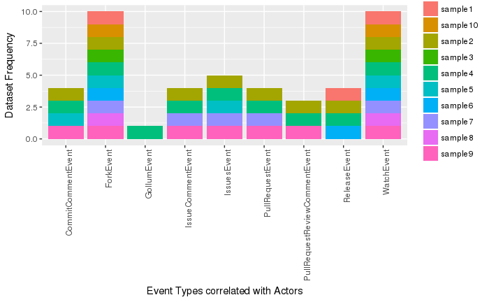

```r
ggplot(samples_events_vs_actors_cor, aes(x=type, fill=dataset)) +
  geom_bar(stat="count") +
  theme(axis.text.x = element_text(angle = 90, hjust = 1)) +
  ylab("Dataset Frequency") +
  xlab("Event Types correlated with Actors") +
ggsave(file="events_repo_samples_event_type_vs_actors.png")
```

```r
samples_events_vs_actors_p_cor <- events_repo_samples %>%
  group_by(dataset, type, participation_rate) %>%
  summarize(events_vs_actors = round(cor(num_events, total_actors))) %>%
  filter(events_vs_actors != 0)
```

[output not shown]

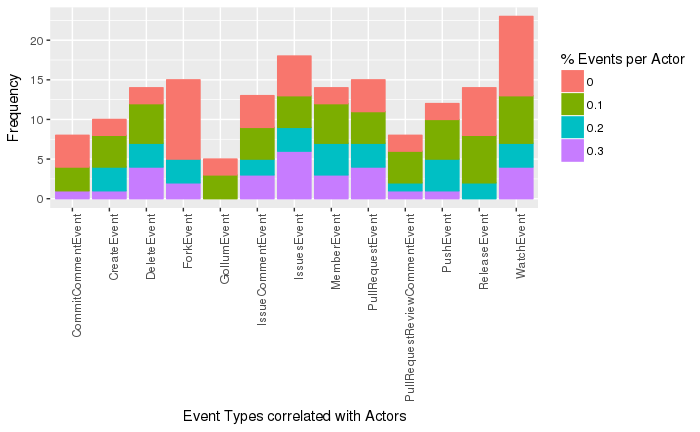

```r
samples_events_vs_actors_p_cor$participation_rate <- factor(samples_events_vs_actors_p_cor$participation_rate)
ggplot(samples_events_vs_actors_p_cor, aes(x=type, colour=participation_rate, fill=participation_rate)) +
  geom_bar(stat="count") +
  labs(fill = "% Events per Actor", colour = "% Events per Actor") +
  theme(axis.text.x = element_text(angle = 90, hjust = 1)) +
  ylab("Frequency") +
  xlab("Event Types correlated with Actors")
ggsave(file="events_repo_samples_event_type_vs_actors_p.png")
```

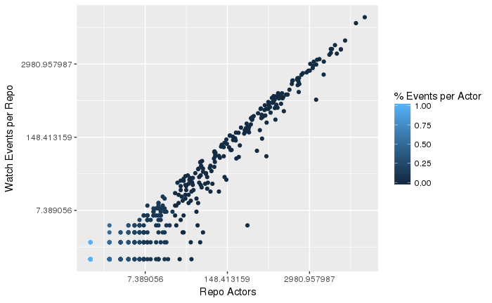

```r
events_repo_samples_watch <- events_repo_samples %>%
  filter(type == "WatchEvent")
ggplot(data = events_repo_samples_watch, aes(y=num_events, x=total_actors,
           fill=participation_rate, colour=participation_rate, group=participation_rate)) +
  labs(colour = "% Events per Actor", fill = "% Events per Actor") +
  geom_point(stat="identity") +
  ylab("Watch Events per Repo") +
  xlab("Repo Actors") +
  scale_x_continuous(trans = "log") +
  scale_y_continuous(trans = "log")
ggsave(file="events_repo_samples_watch.png")
```

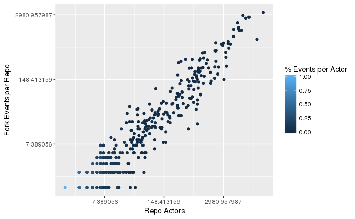

```r
events_repo_samples_fork <- events_repo_samples %>%
  filter(type == "ForkEvent")
ggplot(data = events_repo_samples_fork, aes(y=num_events, x=total_actors,
           fill=participation_rate, colour=participation_rate, group=participation_rate)) +
  labs(colour = "% Events per Actor", fill = "% Events per Actor") +
  geom_point(stat="identity") +
  ylab("Fork Events per Repo") +
  xlab("Repo Actors") +
  scale_x_continuous(trans = "log") +
  scale_y_continuous(trans = "log")
ggsave(file="events_repo_samples_fork.png")
```

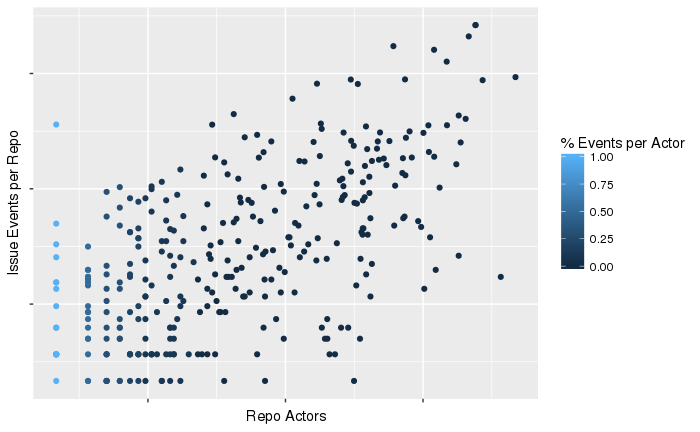

```r
events_repo_samples_issue <- events_repo_samples %>%
  filter(type == "IssuesEvent")
ggplot(data = events_repo_samples_issue, aes(y=num_events, x=total_actors,
           fill=participation_rate, colour=participation_rate, group=participation_rate)) +
  labs(colour = "% Events per Actor", fill = "% Events per Actor") +
  geom_point(stat="identity") +
  ylab("Issue Events per Repo") +
  xlab("Repo Actors") +
  scale_x_continuous(trans = "log", labels=NULL) +
  scale_y_continuous(trans = "log", labels=NULL)
ggsave(file="events_repo_samples_issues.png")
```

### Event Types and Events per Actor

The next series of scatterplots explores the possible correlation between the frequency of an event type and the ratio of events per actor per repository. Ideally a higher events to actor ratio indicates less unique actors per repository. This does not tell us anything about the proportion of those events, so a percentage value has been applied when examining individual event types. The percentage value indicates what percentage of repository events the events per actor ratio represents. A higher percentage indicates the events are spread across a smaller number of actors.

Push events appear to be associated the highest events to actor ratios meaning they are more likely to represent repositories with a smaller number of unique actors. Other event types showed interesting patterns, like Watch and Fork events, that indicated a smaller events to actor ratio overall. For events other than Push events, however there does not appear to be a strong correlation between the frequency an event type occurs for a repository and the distribution of events overall per actor.

```r
samples_events_vs_e2a_cor <- events_repo_samples %>%
  group_by(dataset, type) %>%
  summarize(events_vs_e2a = round(cor(x=num_events, y=events_per_actor))) %>%
  filter(events_vs_e2a != 0) %>%
  arrange(dataset, type)
```

[output not shown]

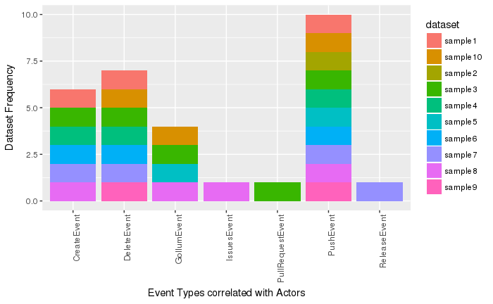

```r
ggplot(samples_events_vs_e2a_cor, aes(x=type, fill=dataset)) +
  geom_bar(stat="count") +
  theme(axis.text.x = element_text(angle = 90, hjust = 1)) +
  ylab("Dataset Frequency") +
  xlab("Event Types correlated with Actors") +
ggsave(file="events_repo_samples_events_per_actor.png")
```

```r
samples_events_vs_e2a_p_cor <- events_repo_samples %>%
  group_by(dataset, participation_rate, type) %>%
  summarize(events_vs_e2a = round(cor(x=num_events, y=events_per_actor))) %>%
  filter(events_vs_e2a != 0) %>%
  arrange(participation_rate, type)
```

[output not shown]

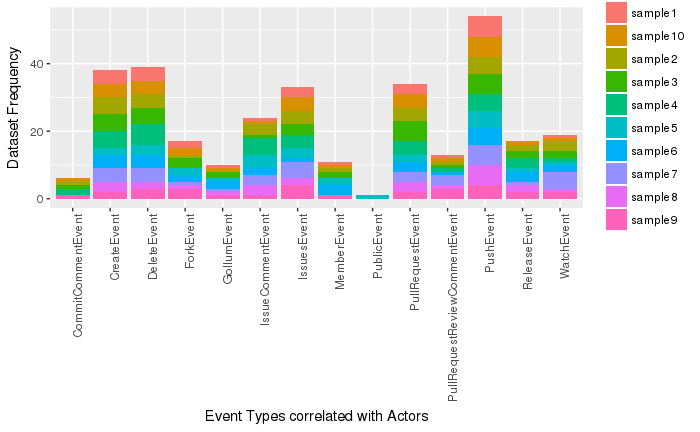

```r
ggplot(samples_events_vs_e2a_p_cor, aes(x=type, fill=dataset)) +
  geom_bar(stat="count") +
  theme(axis.text.x = element_text(angle = 90, hjust = 1)) +
  ylab("Dataset Frequency") +
  xlab("Event Types correlated with Actors") +
ggsave(file="events_repo_samples_events_per_actor_p1.png")
```

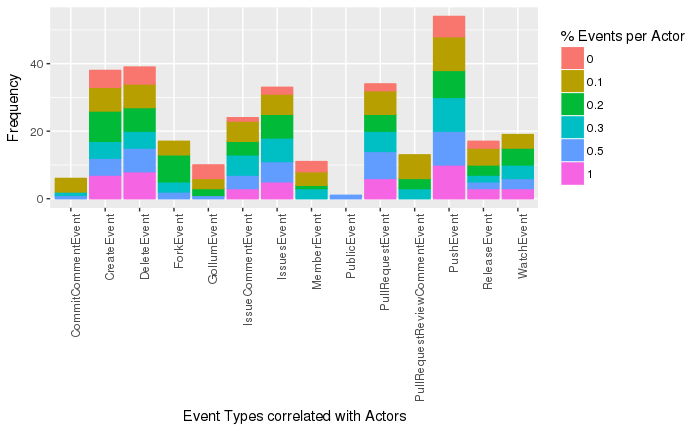

```r
samples_events_vs_e2a_p_cor$participation_rate <- factor(samples_events_vs_e2a_p_cor$participation_rate)
ggplot(samples_events_vs_e2a_p_cor, aes(x=type, colour=participation_rate, fill=participation_rate)) +
  geom_bar(stat="count") +
  labs(fill = "% Events per Actor", colour = "% Events per Actor") +
  theme(axis.text.x = element_text(angle = 90, hjust = 1)) +
  ylab("Frequency") +
  xlab("Event Types correlated with Actors")
ggsave(file="events_repo_samples_events_per_actor_p.png")
```

```r
events_repo_samples_push <- events_repo_samples %>% filter(type == "PushEvent")
```

[output not shown]

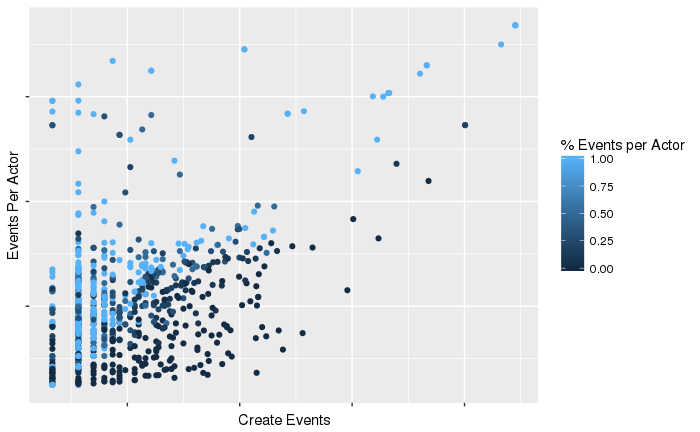

```r
ggplot(data = events_repo_samples_create,
       aes(x=num_events, y=events_per_actor,
           fill=participation_rate, colour=participation_rate, group=participation_rate)) +
  labs(colour = "% Events per Actor", fill = "% Events per Actor") +
  geom_point(stat="identity") +
  xlab("Create Events") +
  ylab("Events Per Actor") +
  scale_x_continuous(trans = "log", labels = NULL) +
  scale_y_continuous(trans = "log", labels = NULL)
ggsave(file="events_repo_samples_create_e2a.png")
```

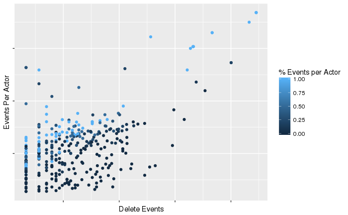

```r
ggplot(data = events_repo_samples_del,
       aes(x=num_events, y=events_per_actor,
           fill=participation_rate, colour=participation_rate, group=participation_rate)) +
  labs(colour = "% Events per Actor", fill = "% Events per Actor") +
  geom_point(stat="identity") +
  xlab("Delete Events") +
  ylab("Events Per Actor") +
  scale_x_continuous(trans = "log", labels = NULL) +
  scale_y_continuous(trans = "log", labels = NULL)
ggsave(file="events_repo_samples_del_e2a.png")
```

# Conclusions

The goal of this study was to determine if there was a relationship between the types of Github events and the number of unique actors that generated those events in each repository. Based on the data analysis presented above, it appears some event types show a possible correlation with overall actor involvement while others do not.

## Next Steps

- Samples of repositories should be taken from the event types of interest and then further analyzed.
- The overall repository event distribution per actor metric should be further evaluated. How effective that metric at categorizing GitHub repositories? How does that metric computed from event data compares to a similar metric computed from actual GitHub repository data?